# Assignment 3: Weather Forecasting with Deep Learning

## Introduction

Weather conditions change over time, making temperature forecasting an interesting problem for deep learning. In this assignment, I will explore how recurrent neural networks can learn patterns from historical weather measurements and use them to predict future temperatures.

My main goal is to compare different neural network architectures and understand how their design affects forecasting performance. I will experiment with GRU, LSTM, and convolutional-recurrent models using the Jena climate dataset.

To make the comparison meaningful, I will evaluate the models using Mean Absolute Error (MAE), apply early stopping during training, and compare their validation results. The strongest models will then be evaluated on the test dataset.

By comparing the results, I hope to identify which architecture provides more accurate temperature predictions and whether additional model complexity improves performance.

```python
# Assignment 3 | Preparing the forecasting environment

import numpy as np
import pandas as pd
import matplotlib.pyplot as plt
import tensorflow as tf

from tensorflow import keras
from tensorflow.keras import layers
from tensorflow.keras.callbacks import EarlyStopping

# Set a seed to make experimental results more reproducible
weather_seed = 37

np.random.seed(weather_seed)
tf.keras.utils.set_random_seed(weather_seed)

# Check the installed TensorFlow version
print("TensorFlow version:", tf.__version__)
print("Weather forecasting environment is ready!")
```

```
TensorFlow version: 2.21.0
Weather forecasting environment is ready!
```

```python
# Step 3 | Downloading the Jena climate dataset

import os
import zipfile

# Download the weather dataset from the TensorFlow-hosted source
climate_archive = keras.utils.get_file(
    fname="jena_climate_2009_2016.csv.zip",
    origin="https://storage.googleapis.com/tensorflow/tf-keras-datasets/jena_climate_2009_2016.csv.zip"
)

# Extract the dataset
with zipfile.ZipFile(climate_archive, "r") as climate_zip:
    climate_zip.extractall("/content/jena_weather")

# Load the weather observations
climate_file = "/content/jena_weather/jena_climate_2009_2016.csv"
climate_records = pd.read_csv(climate_file)

# Display basic dataset information
print("Dataset shape:", climate_records.shape)
print("\nAvailable columns:")
print(climate_records.columns.tolist())

print("\nFirst five observations:")
display(climate_records.head())
```

```
Downloading data from https://storage.googleapis.com/tensorflow/tf-keras-datasets/jena_climate_2009_2016.csv.zip
13568290/13568290 ━━━━━━━━━━━━━━━━━━━━ 0s 0us/step
Dataset shape: (420551, 15)

Available columns:
['Date Time', 'p (mbar)', 'T (degC)', 'Tpot (K)', 'Tdew (degC)', 'rh (%)', 'VPmax (mbar)', 'VPact (mbar)', 'VPdef (mbar)', 'sh (g/kg)', 'H2OC (mmol/mol)', 'rho (g/m**3)', 'wv (m/s)', 'max. wv (m/s)', 'wd (deg)']

First five observations:
```

|  | Date Time | p (mbar) | T (degC) | Tpot (K) | Tdew (degC) | rh (%) | VPmax (mbar) | VPact (mbar) | VPdef (mbar) | sh (g/kg) | H2OC (mmol/mol) | rho (g/m**3) | wv (m/s) | max. wv (m/s) | wd (deg) |
| --- | --- | --- | --- | --- | --- | --- | --- | --- | --- | --- | --- | --- | --- | --- | --- |
| 0 | 01.01.2009 00:10:00 | 996.52 | -8.02 | 265.40 | -8.90 | 93.3 | 3.33 | 3.11 | 0.22 | 1.94 | 3.12 | 1307.75 | 1.03 | 1.75 | 152.3 |
| 1 | 01.01.2009 00:20:00 | 996.57 | -8.41 | 265.01 | -9.28 | 93.4 | 3.23 | 3.02 | 0.21 | 1.89 | 3.03 | 1309.80 | 0.72 | 1.50 | 136.1 |
| 2 | 01.01.2009 00:30:00 | 996.53 | -8.51 | 264.91 | -9.31 | 93.9 | 3.21 | 3.01 | 0.20 | 1.88 | 3.02 | 1310.24 | 0.19 | 0.63 | 171.6 |
| 3 | 01.01.2009 00:40:00 | 996.51 | -8.31 | 265.12 | -9.07 | 94.2 | 3.26 | 3.07 | 0.19 | 1.92 | 3.08 | 1309.19 | 0.34 | 0.50 | 198.0 |
| 4 | 01.01.2009 00:50:00 | 996.51 | -8.27 | 265.15 | -9.04 | 94.1 | 3.27 | 3.08 | 0.19 | 1.92 | 3.09 | 1309.00 | 0.32 | 0.63 | 214.3 |

```
Temperature Summary:
count    420551.000000
mean          9.450147
std           8.423365
min         -23.010000
25%           3.360000
50%           9.420000
75%          15.470000
max          37.280000
Name: T (degC), dtype: float64
```

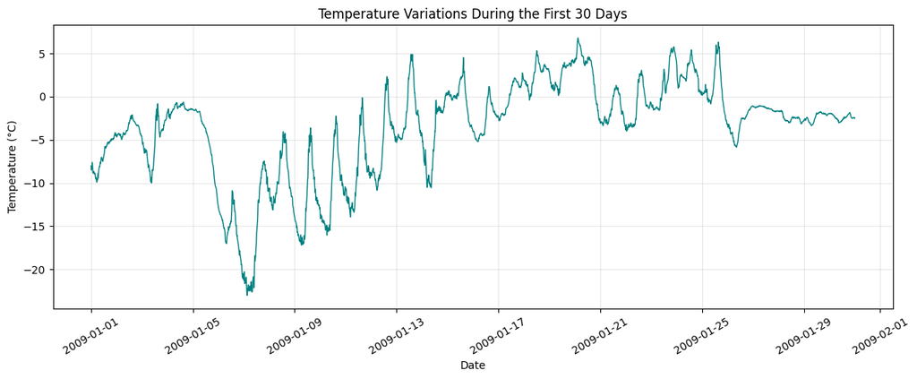

```python
# Step 4 | Exploring temperature patterns in the Jena climate dataset

# Convert the recorded dates into datetime values
climate_records["Date Time"] = pd.to_datetime(
    climate_records["Date Time"],
    format="%d.%m.%Y %H:%M:%S"
)

# Select the temperature observations
temperature_history = climate_records["T (degC)"]

# Display basic temperature statistics
print("Temperature Summary:")
print(temperature_history.describe())

# Plot temperature changes during the first 30 days
plt.figure(figsize=(12, 5))

plt.plot(
    climate_records["Date Time"].iloc[:4320],
    temperature_history.iloc[:4320],
    linewidth=1,
    color="teal"
)

plt.title("Temperature Variations During the First 30 Days")
plt.xlabel("Date")
plt.ylabel("Temperature (°C)")
plt.grid(alpha=0.3)
plt.xticks(rotation=30)
plt.tight_layout()
plt.show()
```

### Interpretation

The temperature graph shows how weather conditions change over time rather than remaining constant. These variations suggest that historical observations may contain useful patterns for predicting future temperatures. By studying these patterns, recurrent neural networks can learn relationships between earlier weather measurements and later temperature values.

```python
# Step 5 | Creating chronological weather data partitions

# Keep the numerical weather measurements
weather_features = climate_records.drop(
    columns=["Date Time"]
).copy()

# Replace invalid wind-speed readings, if present
for wind_column in ["wv (m/s)", "max. wv (m/s)"]:
    weather_features[wind_column] = (
        weather_features[wind_column].clip(lower=0)
    )

# Calculate chronological split boundaries
weather_total_rows = len(weather_features)

weather_train_end = int(weather_total_rows * 0.50)
weather_validation_end = int(weather_total_rows * 0.75)

# Divide the dataset without shuffling
weather_training = weather_features.iloc[:weather_train_end].copy()

weather_validation = weather_features.iloc[
    weather_train_end:weather_validation_end
].copy()

weather_testing = weather_features.iloc[
    weather_validation_end:
].copy()

# Calculate normalization statistics from training data only
weather_training_mean = weather_training.mean()
weather_training_std = weather_training.std().replace(0, 1)

# Apply the same normalization to all three partitions
weather_training_scaled = (
    (weather_training - weather_training_mean) / weather_training_std
)

weather_validation_scaled = (
    (weather_validation - weather_training_mean) / weather_training_std
)

weather_testing_scaled = (
    (weather_testing - weather_training_mean) / weather_training_std
)

# Display the partition sizes
print("Training observations:", len(weather_training_scaled))
print("Validation observations:", len(weather_validation_scaled))
print("Testing observations:", len(weather_testing_scaled))

print("\nTotal observations:", weather_total_rows)
print("Number of weather features:", weather_training_scaled.shape[1])
```

```
Training observations: 210275
Validation observations: 105138
Testing observations: 105138

Total observations: 420551
Number of weather features: 14
```

### Data Preparation and Interpretation

I divided the weather dataset into training, validation, and testing portions while keeping the observations in their original time order. This is important because weather forecasting depends on past measurements, and mixing future observations into the training data could make the evaluation misleading.

I also standardized the numerical features using the mean and standard deviation calculated from the training data. I then applied those same values to the validation and testing sets to keep the preprocessing consistent and avoid using future information during normalization.

```python
# Step 6 | Preparing historical weather sequences

# Use one observation every hour (6 original readings)
weather_hourly_step = 6

# Five days of hourly observations
weather_history_hours = 120

# Forecast temperature 24 hours after the final input
weather_forecast_hours = 24

# Identify the temperature feature
weather_temperature_index = (
    weather_features.columns.get_loc("T (degC)")
)

# Convert normalized datasets to NumPy arrays
weather_train_array = weather_training_scaled.to_numpy(
    dtype="float32"
)

weather_val_array = weather_validation_scaled.to_numpy(
    dtype="float32"
)

weather_test_array = weather_testing_scaled.to_numpy(
    dtype="float32"
)

# Create sequences without crossing dataset boundaries
def build_weather_windows(weather_array):
    weather_hourly = weather_array[::weather_hourly_step]

    weather_inputs = []
    weather_targets = []

    final_start = (
        len(weather_hourly)
        - weather_history_hours
        - weather_forecast_hours
        + 1
    )

    for window_start in range(final_start):
        window_end = window_start + weather_history_hours

        weather_inputs.append(
            weather_hourly[window_start:window_end]
        )

        weather_targets.append(
            weather_hourly[
                window_end + weather_forecast_hours - 1,
                weather_temperature_index
            ]
        )

    return (
        np.asarray(weather_inputs, dtype="float32"),
        np.asarray(weather_targets, dtype="float32")
    )

# Prepare training, validation, and testing sequences
weather_train_x, weather_train_y = build_weather_windows(
    weather_train_array
)

weather_val_x, weather_val_y = build_weather_windows(
    weather_val_array
)

weather_test_x, weather_test_y = build_weather_windows(
    weather_test_array
)

# Confirm the sequence dimensions
print("Training input shape:", weather_train_x.shape)
print("Validation input shape:", weather_val_x.shape)
print("Testing input shape:", weather_test_x.shape)

print("\nTraining target shape:", weather_train_y.shape)
print("Features per timestep:", weather_train_x.shape[2])
```

```
Training input shape: (34903, 120, 14)
Validation input shape: (17380, 120, 14)
Testing input shape: (17380, 120, 14)

Training target shape: (34903,)
Features per timestep: 14
```

### Preparing Time-Series Inputs

I converted the weather measurements into hourly observations to reduce the amount of data processed during training. For each prediction, I used five days of historical weather conditions as input and selected the temperature 24 hours after the final input measurement as the target.

I created the training, validation, and testing sequences separately so that no input window crosses between the datasets. This gives each model the same forecasting task and allows me to compare their performance fairly.

```python
# Step 7 | Training the first GRU weather forecasting model

# Create the GRU architecture
weather_gru_model = keras.Sequential([
    layers.Input(shape=(120, 14)),
    layers.GRU(32),
    layers.Dropout(0.20),
    layers.Dense(1)
])

# Configure the model for temperature prediction
weather_gru_model.compile(
    optimizer=keras.optimizers.Adam(learning_rate=0.001),
    loss="mse",
    metrics=["mae"]
)

# Stop training when validation MAE stops improving
weather_gru_early_stop = EarlyStopping(
    monitor="val_mae",
    patience=5,
    restore_best_weights=True,
    mode="min"
)

# Display model architecture
weather_gru_model.summary()

# Train using the prepared weather sequences
weather_gru_history = weather_gru_model.fit(
    weather_train_x,
    weather_train_y,
    validation_data=(weather_val_x, weather_val_y),
    epochs=30,
    batch_size=128,
    callbacks=[weather_gru_early_stop],
    shuffle=False,
    verbose=1
)

# Record the best validation MAE
weather_gru_best_mae = min(
    weather_gru_history.history["val_mae"]
)

print(
    "\nBest GRU validation MAE (normalized units):",
    round(weather_gru_best_mae, 4)
)
```

```
Model: "sequential"
```

```
┏━━━━━━━━━━━━━━━━━━━━━━━━━━━━━━━━━┳━━━━━━━━━━━━━━━━━━━━━━━━┳━━━━━━━━━━━━━━━┓
┃ Layer (type)                    ┃ Output Shape           ┃       Param # ┃
┡━━━━━━━━━━━━━━━━━━━━━━━━━━━━━━━━━╇━━━━━━━━━━━━━━━━━━━━━━━━╇━━━━━━━━━━━━━━━┩
│ gru (GRU)                       │ (None, 32)             │         4,608 │
├─────────────────────────────────┼────────────────────────┼───────────────┤
│ dropout (Dropout)               │ (None, 32)             │             0 │
├─────────────────────────────────┼────────────────────────┼───────────────┤
│ dense (Dense)                   │ (None, 1)              │            33 │
└─────────────────────────────────┴────────────────────────┴───────────────┘
```

```
 Total params: 4,641 (18.13 KB)
```

```
 Trainable params: 4,641 (18.13 KB)
```

```
 Non-trainable params: 0 (0.00 B)
```

```
273/273 ━━━━━━━━━━━━━━━━━━━━ 7s 12ms/step - loss: 0.3354 - mae: 0.4288 - val_loss: 0.1392 - val_mae: 0.2913
273/273 ━━━━━━━━━━━━━━━━━━━━ 3s 10ms/step - loss: 0.1940 - mae: 0.3439 - val_loss: 0.1420 - val_mae: 0.2939
273/273 ━━━━━━━━━━━━━━━━━━━━ 3s 10ms/step - loss: 0.1768 - mae: 0.3285 - val_loss: 0.1350 - val_mae: 0.2867
273/273 ━━━━━━━━━━━━━━━━━━━━ 3s 11ms/step - loss: 0.1685 - mae: 0.3218 - val_loss: 0.1326 - val_mae: 0.2838
273/273 ━━━━━━━━━━━━━━━━━━━━ 3s 12ms/step - loss: 0.1628 - mae: 0.3154 - val_loss: 0.1287 - val_mae: 0.2796
273/273 ━━━━━━━━━━━━━━━━━━━━ 3s 10ms/step - loss: 0.1590 - mae: 0.3114 - val_loss: 0.1273 - val_mae: 0.2779
273/273 ━━━━━━━━━━━━━━━━━━━━ 3s 10ms/step - loss: 0.1563 - mae: 0.3089 - val_loss: 0.1247 - val_mae: 0.2751
273/273 ━━━━━━━━━━━━━━━━━━━━ 3s 10ms/step - loss: 0.1547 - mae: 0.3072 - val_loss: 0.1232 - val_mae: 0.2734
273/273 ━━━━━━━━━━━━━━━━━━━━ 4s 13ms/step - loss: 0.1533 - mae: 0.3055 - val_loss: 0.1236 - val_mae: 0.2737
273/273 ━━━━━━━━━━━━━━━━━━━━ 3s 10ms/step - loss: 0.1526 - mae: 0.3048 - val_loss: 0.1207 - val_mae: 0.2704
273/273 ━━━━━━━━━━━━━━━━━━━━ 3s 10ms/step - loss: 0.1503 - mae: 0.3018 - val_loss: 0.1230 - val_mae: 0.2729
273/273 ━━━━━━━━━━━━━━━━━━━━ 5s 11ms/step - loss: 0.1515 - mae: 0.3037 - val_loss: 0.1218 - val_mae: 0.2716
273/273 ━━━━━━━━━━━━━━━━━━━━ 5s 10ms/step - loss: 0.1492 - mae: 0.3013 - val_loss: 0.1209 - val_mae: 0.2707
273/273 ━━━━━━━━━━━━━━━━━━━━ 3s 10ms/step - loss: 0.1483 - mae: 0.3007 - val_loss: 0.1213 - val_mae: 0.2710
273/273 ━━━━━━━━━━━━━━━━━━━━ 3s 10ms/step - loss: 0.1485 - mae: 0.3005 - val_loss: 0.1208 - val_mae: 0.2705

Best GRU validation MAE (normalized units): 0.2704
```

### GRU Model Interpretation

I started with a GRU-based neural network to establish an initial forecasting model. The GRU layer uses historical weather observations to learn patterns that may help predict future temperatures. I also included dropout to reduce overfitting.

During training, I monitored validation Mean Absolute Error (MAE) and applied early stopping with a patience of five epochs. This allowed training to stop when the model was no longer improving on the validation data, while restoring the weights from its best-performing epoch.

I will use the GRU model's validation MAE as a reference when comparing it with the other architectures.

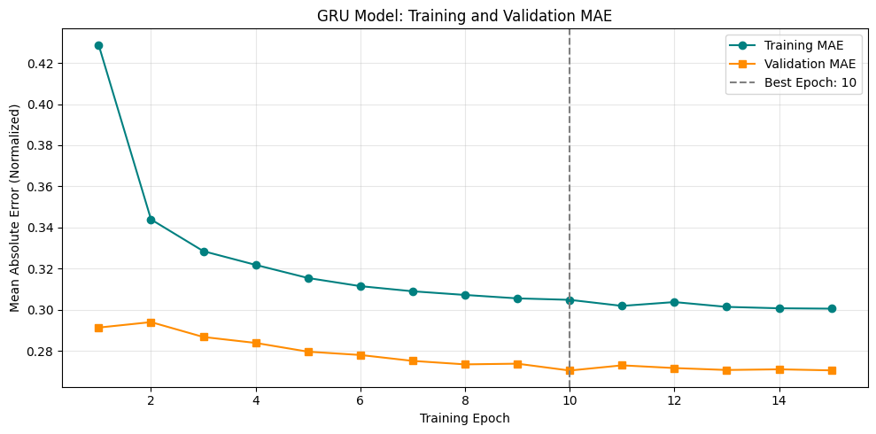

```
Best validation epoch: 10
Best validation MAE: 0.2704
Total epochs completed: 15
```

```python
# Step 8 | Visualizing GRU forecasting performance

# Retrieve the recorded training results
gru_training_mae = weather_gru_history.history["mae"]
gru_validation_mae = weather_gru_history.history["val_mae"]

# Create epoch numbers
gru_epoch_numbers = range(1, len(gru_training_mae) + 1)

# Identify the best validation epoch
gru_best_epoch = np.argmin(gru_validation_mae) + 1

# Plot training and validation MAE
plt.figure(figsize=(10, 5))

plt.plot(
    gru_epoch_numbers,
    gru_training_mae,
    marker="o",
    label="Training MAE",
    color="teal"
)

plt.plot(
    gru_epoch_numbers,
    gru_validation_mae,
    marker="s",
    label="Validation MAE",
    color="darkorange"
)

plt.axvline(
    x=gru_best_epoch,
    linestyle="--",
    color="gray",
    label=f"Best Epoch: {gru_best_epoch}"
)

plt.title("GRU Model: Training and Validation MAE")
plt.xlabel("Training Epoch")
plt.ylabel("Mean Absolute Error (Normalized)")
plt.legend()
plt.grid(alpha=0.3)
plt.tight_layout()
plt.show()

print("Best validation epoch:", gru_best_epoch)
print("Best validation MAE:", round(min(gru_validation_mae), 4))
print("Total epochs completed:", len(gru_training_mae))
```

### GRU Training Performance Interpretation

The GRU model showed steady improvement during training. Its validation MAE decreased from 0.2913 in the first epoch to its lowest value of 0.2704 at epoch 10.

Although the training error continued to decrease, the validation error did not improve after epoch 10. This suggests that additional training was no longer providing a meaningful improvement on unseen validation data.

Early stopping ended the training process after 15 epochs and restored the model weights from epoch 10. This helped avoid unnecessary training while preserving the best validation performance.

The GRU model provides an initial benchmark for comparing the other forecasting architectures.

```python
# Step 9 | Training an LSTM model for weather prediction

# Build the LSTM architecture
weather_lstm_model = keras.Sequential([
    layers.Input(shape=(120, 14)),
    layers.LSTM(32),
    layers.Dropout(0.20),
    layers.Dense(1)
])

# Compile the model using the same settings as GRU
weather_lstm_model.compile(
    optimizer=keras.optimizers.Adam(learning_rate=0.001),
    loss="mse",
    metrics=["mae"]
)

# Apply early stopping based on validation MAE
weather_lstm_early_stop = EarlyStopping(
    monitor="val_mae",
    patience=5,
    restore_best_weights=True,
    mode="min"
)

# Display the LSTM model architecture
weather_lstm_model.summary()

# Train the LSTM model
weather_lstm_history = weather_lstm_model.fit(
    weather_train_x,
    weather_train_y,
    validation_data=(weather_val_x, weather_val_y),
    epochs=30,
    batch_size=128,
    callbacks=[weather_lstm_early_stop],
    shuffle=False,
    verbose=1
)

# Record the best LSTM validation performance
weather_lstm_best_mae = min(
    weather_lstm_history.history["val_mae"]
)

weather_lstm_best_epoch = (
    np.argmin(weather_lstm_history.history["val_mae"]) + 1
)

print("\nBest LSTM validation MAE:",
      round(weather_lstm_best_mae, 4))

print("Best LSTM epoch:", weather_lstm_best_epoch)

print("Total epochs completed:",
      len(weather_lstm_history.history["mae"]))
```

```
Model: "sequential_1"
```

```
┏━━━━━━━━━━━━━━━━━━━━━━━━━━━━━━━━━┳━━━━━━━━━━━━━━━━━━━━━━━━┳━━━━━━━━━━━━━━━┓
┃ Layer (type)                    ┃ Output Shape           ┃       Param # ┃
┡━━━━━━━━━━━━━━━━━━━━━━━━━━━━━━━━━╇━━━━━━━━━━━━━━━━━━━━━━━━╇━━━━━━━━━━━━━━━┩
│ lstm (LSTM)                     │ (None, 32)             │         6,016 │
├─────────────────────────────────┼────────────────────────┼───────────────┤
│ dropout_1 (Dropout)             │ (None, 32)             │             0 │
├─────────────────────────────────┼────────────────────────┼───────────────┤
│ dense_1 (Dense)                 │ (None, 1)              │            33 │
└─────────────────────────────────┴────────────────────────┴───────────────┘
```

```
 Total params: 6,049 (23.63 KB)
```

```
 Trainable params: 6,049 (23.63 KB)
```

```
 Non-trainable params: 0 (0.00 B)
```

```
273/273 ━━━━━━━━━━━━━━━━━━━━ 5s 13ms/step - loss: 0.2804 - mae: 0.4069 - val_loss: 0.1342 - val_mae: 0.2879
273/273 ━━━━━━━━━━━━━━━━━━━━ 3s 10ms/step - loss: 0.1843 - mae: 0.3371 - val_loss: 0.1298 - val_mae: 0.2825
273/273 ━━━━━━━━━━━━━━━━━━━━ 3s 11ms/step - loss: 0.1717 - mae: 0.3243 - val_loss: 0.1273 - val_mae: 0.2793
273/273 ━━━━━━━━━━━━━━━━━━━━ 3s 12ms/step - loss: 0.1647 - mae: 0.3174 - val_loss: 0.1252 - val_mae: 0.2763
273/273 ━━━━━━━━━━━━━━━━━━━━ 3s 10ms/step - loss: 0.1619 - mae: 0.3140 - val_loss: 0.1239 - val_mae: 0.2746
273/273 ━━━━━━━━━━━━━━━━━━━━ 3s 10ms/step - loss: 0.1578 - mae: 0.3107 - val_loss: 0.1228 - val_mae: 0.2733
273/273 ━━━━━━━━━━━━━━━━━━━━ 3s 10ms/step - loss: 0.1566 - mae: 0.3088 - val_loss: 0.1228 - val_mae: 0.2732
273/273 ━━━━━━━━━━━━━━━━━━━━ 4s 15ms/step - loss: 0.1553 - mae: 0.3080 - val_loss: 0.1223 - val_mae: 0.2726
273/273 ━━━━━━━━━━━━━━━━━━━━ 3s 10ms/step - loss: 0.1539 - mae: 0.3060 - val_loss: 0.1223 - val_mae: 0.2726
273/273 ━━━━━━━━━━━━━━━━━━━━ 3s 10ms/step - loss: 0.1524 - mae: 0.3047 - val_loss: 0.1215 - val_mae: 0.2717
273/273 ━━━━━━━━━━━━━━━━━━━━ 3s 10ms/step - loss: 0.1517 - mae: 0.3037 - val_loss: 0.1215 - val_mae: 0.2719
273/273 ━━━━━━━━━━━━━━━━━━━━ 5s 11ms/step - loss: 0.1506 - mae: 0.3028 - val_loss: 0.1207 - val_mae: 0.2710
273/273 ━━━━━━━━━━━━━━━━━━━━ 3s 10ms/step - loss: 0.1502 - mae: 0.3025 - val_loss: 0.1211 - val_mae: 0.2714
273/273 ━━━━━━━━━━━━━━━━━━━━ 3s 10ms/step - loss: 0.1496 - mae: 0.3013 - val_loss: 0.1202 - val_mae: 0.2706
273/273 ━━━━━━━━━━━━━━━━━━━━ 3s 12ms/step - loss: 0.1495 - mae: 0.3013 - val_loss: 0.1198 - val_mae: 0.2698
273/273 ━━━━━━━━━━━━━━━━━━━━ 3s 12ms/step - loss: 0.1483 - mae: 0.3002 - val_loss: 0.1204 - val_mae: 0.2709
273/273 ━━━━━━━━━━━━━━━━━━━━ 3s 10ms/step - loss: 0.1465 - mae: 0.2982 - val_loss: 0.1198 - val_mae: 0.2698
273/273 ━━━━━━━━━━━━━━━━━━━━ 3s 10ms/step - loss: 0.1464 - mae: 0.2983 - val_loss: 0.1201 - val_mae: 0.2706
273/273 ━━━━━━━━━━━━━━━━━━━━ 3s 10ms/step - loss: 0.1450 - mae: 0.2970 - val_loss: 0.1191 - val_mae: 0.2693
273/273 ━━━━━━━━━━━━━━━━━━━━ 4s 13ms/step - loss: 0.1458 - mae: 0.2975 - val_loss: 0.1182 - val_mae: 0.2677
273/273 ━━━━━━━━━━━━━━━━━━━━ 3s 10ms/step - loss: 0.1437 - mae: 0.2956 - val_loss: 0.1183 - val_mae: 0.2681
273/273 ━━━━━━━━━━━━━━━━━━━━ 3s 10ms/step - loss: 0.1430 - mae: 0.2948 - val_loss: 0.1177 - val_mae: 0.2670
273/273 ━━━━━━━━━━━━━━━━━━━━ 3s 10ms/step - loss: 0.1426 - mae: 0.2946 - val_loss: 0.1169 - val_mae: 0.2658
273/273 ━━━━━━━━━━━━━━━━━━━━ 4s 13ms/step - loss: 0.1428 - mae: 0.2947 - val_loss: 0.1170 - val_mae: 0.2662
273/273 ━━━━━━━━━━━━━━━━━━━━ 3s 10ms/step - loss: 0.1420 - mae: 0.2938 - val_loss: 0.1165 - val_mae: 0.2656
273/273 ━━━━━━━━━━━━━━━━━━━━ 3s 10ms/step - loss: 0.1404 - mae: 0.2925 - val_loss: 0.1173 - val_mae: 0.2665
273/273 ━━━━━━━━━━━━━━━━━━━━ 3s 10ms/step - loss: 0.1400 - mae: 0.2923 - val_loss: 0.1153 - val_mae: 0.2637
273/273 ━━━━━━━━━━━━━━━━━━━━ 3s 12ms/step - loss: 0.1394 - mae: 0.2912 - val_loss: 0.1168 - val_mae: 0.2658
273/273 ━━━━━━━━━━━━━━━━━━━━ 3s 11ms/step - loss: 0.1380 - mae: 0.2893 - val_loss: 0.1159 - val_mae: 0.2647
273/273 ━━━━━━━━━━━━━━━━━━━━ 3s 10ms/step - loss: 0.1382 - mae: 0.2899 - val_loss: 0.1170 - val_mae: 0.2661

Best LSTM validation MAE: 0.2637
Best LSTM epoch: 27
Total epochs completed: 30
```

### LSTM Model Interpretation

I developed an LSTM model to investigate whether a different recurrent architecture could improve temperature forecasting. Like the GRU model, the LSTM uses five days of historical weather observations to predict the temperature 24 hours ahead.

I kept the number of recurrent units, dropout rate, optimizer, batch size, and early stopping settings consistent with the GRU experiment. This allows me to compare the two architectures under similar training conditions.

I monitored validation MAE throughout training and used early stopping to restore the model weights from the best-performing epoch. The resulting validation MAE will help determine which recurrent architecture performs better on this forecasting task.

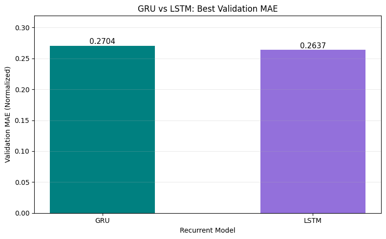

```
Better validation model: LSTM
Difference in validation MAE: 0.0066
```

```python
# Step 10 | Comparing GRU and LSTM validation performance

# Collect the best validation errors
recurrent_model_names = ["GRU", "LSTM"]

recurrent_validation_scores = [
    weather_gru_best_mae,
    weather_lstm_best_mae
]

# Create a visual comparison
plt.figure(figsize=(8, 5))

comparison_bars = plt.bar(
    recurrent_model_names,
    recurrent_validation_scores,
    color=["teal", "mediumpurple"],
    width=0.5
)

# Display each model's validation MAE
for comparison_bar, model_score in zip(
    comparison_bars, recurrent_validation_scores
):
    plt.text(
        comparison_bar.get_x() + comparison_bar.get_width() / 2,
        comparison_bar.get_height() + 0.003,
        f"{model_score:.4f}",
        ha="center",
        fontsize=11
    )

plt.title("GRU vs LSTM: Best Validation MAE")
plt.xlabel("Recurrent Model")
plt.ylabel("Validation MAE (Normalized)")
plt.ylim(0, max(recurrent_validation_scores) * 1.18)
plt.grid(axis="y", alpha=0.25)
plt.tight_layout()
plt.show()

# Identify the better model
recurrent_best_index = np.argmin(
    recurrent_validation_scores
)

print(
    "Better validation model:",
    recurrent_model_names[recurrent_best_index]
)

print(
    "Difference in validation MAE:",
    round(
        abs(weather_gru_best_mae - weather_lstm_best_mae),
        4
    )
)
```

### Comparison of GRU and LSTM Models

I compared the GRU and LSTM models using their lowest validation Mean Absolute Error (MAE). The GRU model achieved a validation MAE of 0.2704, while the LSTM model achieved a slightly lower value of 0.2637.

Based on these results, LSTM performed better on the validation dataset, reducing the error by approximately 2.48% compared with GRU. However, the difference was relatively small, suggesting that both recurrent architectures were capable of learning useful patterns from the historical weather measurements.

The LSTM model reached its best performance at epoch 27, while GRU reached its best performance at epoch 10. This also shows that the two models followed different training patterns.

At this stage, LSTM is the better-performing model, but I will continue experimenting with additional architectures before selecting the final model for testing.

```python
# Step 11 | Exploring a deeper GRU forecasting architecture

# Build a stacked GRU model with two recurrent layers
weather_stacked_gru_model = keras.Sequential([
    layers.Input(shape=(120, 14)),

    # First GRU layer retains the full sequence
    layers.GRU(64, return_sequences=True),
    layers.Dropout(0.20),

    # Second GRU layer summarizes learned patterns
    layers.GRU(32),
    layers.Dropout(0.20),

    # Produce one future temperature prediction
    layers.Dense(1)
])

# Configure the stacked GRU model
weather_stacked_gru_model.compile(
    optimizer=keras.optimizers.Adam(learning_rate=0.001),
    loss="mse",
    metrics=["mae"]
)

# Monitor validation error to prevent unnecessary training
weather_stacked_gru_early_stop = EarlyStopping(
    monitor="val_mae",
    patience=5,
    restore_best_weights=True,
    mode="min"
)

# Display the architecture
weather_stacked_gru_model.summary()

# Train the stacked GRU network
weather_stacked_gru_history = weather_stacked_gru_model.fit(
    weather_train_x,
    weather_train_y,
    validation_data=(weather_val_x, weather_val_y),
    epochs=30,
    batch_size=128,
    callbacks=[weather_stacked_gru_early_stop],
    shuffle=False,
    verbose=1
)

# Extract the best validation performance
weather_stacked_gru_best_mae = min(
    weather_stacked_gru_history.history["val_mae"]
)

weather_stacked_gru_best_epoch = (
    np.argmin(
        weather_stacked_gru_history.history["val_mae"]
    ) + 1
)

print(
    "\nBest stacked GRU validation MAE:",
    round(weather_stacked_gru_best_mae, 4)
)

print(
    "Best stacked GRU epoch:",
    weather_stacked_gru_best_epoch
)

print(
    "Total epochs completed:",
    len(weather_stacked_gru_history.history["mae"])
)
```

```
Model: "sequential_2"
```

```
┏━━━━━━━━━━━━━━━━━━━━━━━━━━━━━━━━━┳━━━━━━━━━━━━━━━━━━━━━━━━┳━━━━━━━━━━━━━━━┓
┃ Layer (type)                    ┃ Output Shape           ┃       Param # ┃
┡━━━━━━━━━━━━━━━━━━━━━━━━━━━━━━━━━╇━━━━━━━━━━━━━━━━━━━━━━━━╇━━━━━━━━━━━━━━━┩
│ gru_1 (GRU)                     │ (None, 120, 64)        │        15,360 │
├─────────────────────────────────┼────────────────────────┼───────────────┤
│ dropout_2 (Dropout)             │ (None, 120, 64)        │             0 │
├─────────────────────────────────┼────────────────────────┼───────────────┤
│ gru_2 (GRU)                     │ (None, 32)             │         9,408 │
├─────────────────────────────────┼────────────────────────┼───────────────┤
│ dropout_3 (Dropout)             │ (None, 32)             │             0 │
├─────────────────────────────────┼────────────────────────┼───────────────┤
│ dense_2 (Dense)                 │ (None, 1)              │            33 │
└─────────────────────────────────┴────────────────────────┴───────────────┘
```

```
 Total params: 24,801 (96.88 KB)
```

```
 Trainable params: 24,801 (96.88 KB)
```

```
 Non-trainable params: 0 (0.00 B)
```

```
273/273 ━━━━━━━━━━━━━━━━━━━━ 6s 18ms/step - loss: 0.2409 - mae: 0.3805 - val_loss: 0.1460 - val_mae: 0.3013
273/273 ━━━━━━━━━━━━━━━━━━━━ 5s 16ms/step - loss: 0.1831 - mae: 0.3345 - val_loss: 0.1453 - val_mae: 0.2976
273/273 ━━━━━━━━━━━━━━━━━━━━ 4s 15ms/step - loss: 0.1756 - mae: 0.3280 - val_loss: 0.1414 - val_mae: 0.2931
273/273 ━━━━━━━━━━━━━━━━━━━━ 5s 17ms/step - loss: 0.1692 - mae: 0.3213 - val_loss: 0.1424 - val_mae: 0.2940
273/273 ━━━━━━━━━━━━━━━━━━━━ 5s 17ms/step - loss: 0.1663 - mae: 0.3190 - val_loss: 0.1427 - val_mae: 0.2940
273/273 ━━━━━━━━━━━━━━━━━━━━ 4s 14ms/step - loss: 0.1648 - mae: 0.3179 - val_loss: 0.1435 - val_mae: 0.2949
273/273 ━━━━━━━━━━━━━━━━━━━━ 5s 17ms/step - loss: 0.1631 - mae: 0.3165 - val_loss: 0.1425 - val_mae: 0.2937
273/273 ━━━━━━━━━━━━━━━━━━━━ 4s 14ms/step - loss: 0.1628 - mae: 0.3162 - val_loss: 0.1397 - val_mae: 0.2910
273/273 ━━━━━━━━━━━━━━━━━━━━ 4s 16ms/step - loss: 0.1616 - mae: 0.3146 - val_loss: 0.1390 - val_mae: 0.2902
273/273 ━━━━━━━━━━━━━━━━━━━━ 5s 18ms/step - loss: 0.1595 - mae: 0.3119 - val_loss: 0.1369 - val_mae: 0.2879
273/273 ━━━━━━━━━━━━━━━━━━━━ 4s 14ms/step - loss: 0.1599 - mae: 0.3131 - val_loss: 0.1354 - val_mae: 0.2863
273/273 ━━━━━━━━━━━━━━━━━━━━ 4s 14ms/step - loss: 0.1574 - mae: 0.3111 - val_loss: 0.1359 - val_mae: 0.2867
273/273 ━━━━━━━━━━━━━━━━━━━━ 5s 18ms/step - loss: 0.1571 - mae: 0.3103 - val_loss: 0.1333 - val_mae: 0.2839
273/273 ━━━━━━━━━━━━━━━━━━━━ 4s 14ms/step - loss: 0.1557 - mae: 0.3086 - val_loss: 0.1314 - val_mae: 0.2818
273/273 ━━━━━━━━━━━━━━━━━━━━ 4s 14ms/step - loss: 0.1540 - mae: 0.3068 - val_loss: 0.1262 - val_mae: 0.2766
273/273 ━━━━━━━━━━━━━━━━━━━━ 5s 18ms/step - loss: 0.1526 - mae: 0.3052 - val_loss: 0.1268 - val_mae: 0.2772
273/273 ━━━━━━━━━━━━━━━━━━━━ 4s 15ms/step - loss: 0.1511 - mae: 0.3036 - val_loss: 0.1291 - val_mae: 0.2796
273/273 ━━━━━━━━━━━━━━━━━━━━ 4s 14ms/step - loss: 0.1494 - mae: 0.3019 - val_loss: 0.1262 - val_mae: 0.2765
273/273 ━━━━━━━━━━━━━━━━━━━━ 5s 18ms/step - loss: 0.1477 - mae: 0.3005 - val_loss: 0.1283 - val_mae: 0.2787
273/273 ━━━━━━━━━━━━━━━━━━━━ 4s 14ms/step - loss: 0.1448 - mae: 0.2974 - val_loss: 0.1287 - val_mae: 0.2788
273/273 ━━━━━━━━━━━━━━━━━━━━ 4s 14ms/step - loss: 0.1436 - mae: 0.2963 - val_loss: 0.1268 - val_mae: 0.2775
273/273 ━━━━━━━━━━━━━━━━━━━━ 5s 18ms/step - loss: 0.1399 - mae: 0.2923 - val_loss: 0.1274 - val_mae: 0.2764
273/273 ━━━━━━━━━━━━━━━━━━━━ 4s 14ms/step - loss: 0.1397 - mae: 0.2925 - val_loss: 0.1238 - val_mae: 0.2741
273/273 ━━━━━━━━━━━━━━━━━━━━ 4s 14ms/step - loss: 0.1375 - mae: 0.2898 - val_loss: 0.1255 - val_mae: 0.2755
273/273 ━━━━━━━━━━━━━━━━━━━━ 5s 17ms/step - loss: 0.1338 - mae: 0.2861 - val_loss: 0.1331 - val_mae: 0.2834
273/273 ━━━━━━━━━━━━━━━━━━━━ 4s 15ms/step - loss: 0.1313 - mae: 0.2836 - val_loss: 0.1304 - val_mae: 0.2806
273/273 ━━━━━━━━━━━━━━━━━━━━ 4s 14ms/step - loss: 0.1288 - mae: 0.2815 - val_loss: 0.1276 - val_mae: 0.2779
273/273 ━━━━━━━━━━━━━━━━━━━━ 5s 18ms/step - loss: 0.1267 - mae: 0.2789 - val_loss: 0.1303 - val_mae: 0.2813

Best stacked GRU validation MAE: 0.2741
Best stacked GRU epoch: 23
Total epochs completed: 28
```

### Stacked GRU Model Interpretation

I experimented with a deeper GRU architecture to investigate whether adding another recurrent layer could improve weather forecasting. Unlike my first GRU model, which contained a single recurrent layer with 32 units, this model uses two GRU layers containing 64 and 32 units.

The first GRU layer returns the complete sequence of learned features, allowing the second GRU layer to process those patterns before producing the final temperature prediction. I also included dropout after both recurrent layers to help reduce overfitting.

I used the same training and validation datasets, optimizer settings, and early stopping approach as the earlier models. This experiment will help me understand whether a deeper recurrent architecture provides better forecasting performance than the simpler GRU and LSTM models.

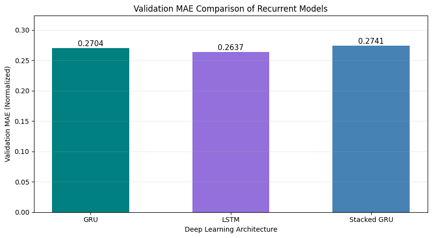

```
Current best forecasting model: LSTM
Lowest validation MAE: 0.2637
```

```python
# Step 12 | Comparing three recurrent forecasting models

# Store the validation results from each experiment
weather_model_labels = [
    "GRU",
    "LSTM",
    "Stacked GRU"
]

weather_model_mae_scores = [
    weather_gru_best_mae,
    weather_lstm_best_mae,
    weather_stacked_gru_best_mae
]

# Create a bar chart of validation MAE
plt.figure(figsize=(9, 5))

weather_comparison_bars = plt.bar(
    weather_model_labels,
    weather_model_mae_scores,
    color=["teal", "mediumpurple", "steelblue"],
    width=0.55
)

# Add actual error values above the bars
for weather_bar, weather_score in zip(
    weather_comparison_bars,
    weather_model_mae_scores
):
    plt.text(
        weather_bar.get_x() + weather_bar.get_width() / 2,
        weather_bar.get_height() + 0.003,
        f"{weather_score:.4f}",
        ha="center",
        fontsize=11
    )

plt.title("Validation MAE Comparison of Recurrent Models")
plt.xlabel("Deep Learning Architecture")
plt.ylabel("Validation MAE (Normalized)")
plt.ylim(0, max(weather_model_mae_scores) * 1.18)
plt.grid(axis="y", alpha=0.25)
plt.tight_layout()
plt.show()

# Identify the model with the lowest validation error
weather_best_model_position = np.argmin(
    weather_model_mae_scores
)

print(
    "Current best forecasting model:",
    weather_model_labels[weather_best_model_position]
)

print(
    "Lowest validation MAE:",
    round(min(weather_model_mae_scores), 4)
)
```

### Comparison of Recurrent Network Architectures

I compared three recurrent neural network architectures to understand how different layer configurations affect weather forecasting accuracy.

The single-layer GRU achieved a validation MAE of 0.2704, while the LSTM achieved the lowest validation MAE of 0.2637. The stacked GRU model, which used two recurrent layers with 64 and 32 units, produced a slightly higher validation MAE of 0.2741.

These results show that increasing the number of recurrent layers did not automatically improve forecasting performance. Although the stacked GRU had a more complex architecture, it performed slightly worse than the simpler GRU and LSTM models.

Among the three models, LSTM provided the best validation performance. I will continue exploring a convolutional and recurrent hybrid architecture before selecting the final model for testing.

```python
# Step 13 | Combining convolutional and recurrent layers

# Create the Conv1D + GRU hybrid architecture
weather_hybrid_model = keras.Sequential([
    layers.Input(shape=(120, 14)),

    # Extract local patterns from historical weather readings
    layers.Conv1D(
        filters=32,
        kernel_size=3,
        activation="relu",
        padding="same"
    ),

    # Reduce the sequence length for efficient training
    layers.MaxPooling1D(pool_size=2),

    # Learn sequential relationships from extracted features
    layers.GRU(32),

    # Reduce the chance of overfitting
    layers.Dropout(0.20),

    # Predict the future temperature
    layers.Dense(1)
])

# Compile using the same optimizer and evaluation metric
weather_hybrid_model.compile(
    optimizer=keras.optimizers.Adam(learning_rate=0.001),
    loss="mse",
    metrics=["mae"]
)

# Stop training when validation performance stops improving
weather_hybrid_early_stop = EarlyStopping(
    monitor="val_mae",
    patience=5,
    restore_best_weights=True,
    mode="min"
)

# Display the hybrid model structure
weather_hybrid_model.summary()

# Train the hybrid forecasting model
weather_hybrid_history = weather_hybrid_model.fit(
    weather_train_x,
    weather_train_y,
    validation_data=(weather_val_x, weather_val_y),
    epochs=30,
    batch_size=128,
    callbacks=[weather_hybrid_early_stop],
    shuffle=False,
    verbose=1
)

# Identify the best validation performance
weather_hybrid_best_mae = min(
    weather_hybrid_history.history["val_mae"]
)

weather_hybrid_best_epoch = (
    np.argmin(weather_hybrid_history.history["val_mae"]) + 1
)

print(
    "\nBest Conv1D + GRU validation MAE:",
    round(weather_hybrid_best_mae, 4)
)

print(
    "Best hybrid model epoch:",
    weather_hybrid_best_epoch
)

print(
    "Total epochs completed:",
    len(weather_hybrid_history.history["mae"])
)
```

```
Model: "sequential_3"
```

```
┏━━━━━━━━━━━━━━━━━━━━━━━━━━━━━━━━━┳━━━━━━━━━━━━━━━━━━━━━━━━┳━━━━━━━━━━━━━━━┓
┃ Layer (type)                    ┃ Output Shape           ┃       Param # ┃
┡━━━━━━━━━━━━━━━━━━━━━━━━━━━━━━━━━╇━━━━━━━━━━━━━━━━━━━━━━━━╇━━━━━━━━━━━━━━━┩
│ conv1d (Conv1D)                 │ (None, 120, 32)        │         1,376 │
├─────────────────────────────────┼────────────────────────┼───────────────┤
│ max_pooling1d (MaxPooling1D)    │ (None, 60, 32)         │             0 │
├─────────────────────────────────┼────────────────────────┼───────────────┤
│ gru_3 (GRU)                     │ (None, 32)             │         6,336 │
├─────────────────────────────────┼────────────────────────┼───────────────┤
│ dropout_4 (Dropout)             │ (None, 32)             │             0 │
├─────────────────────────────────┼────────────────────────┼───────────────┤
│ dense_3 (Dense)                 │ (None, 1)              │            33 │
└─────────────────────────────────┴────────────────────────┴───────────────┘
```

```
 Total params: 7,745 (30.25 KB)
```

```
 Trainable params: 7,745 (30.25 KB)
```

```
 Non-trainable params: 0 (0.00 B)
```

```
273/273 ━━━━━━━━━━━━━━━━━━━━ 6s 15ms/step - loss: 0.3421 - mae: 0.4463 - val_loss: 0.2258 - val_mae: 0.3658
273/273 ━━━━━━━━━━━━━━━━━━━━ 2s 9ms/step - loss: 0.2030 - mae: 0.3541 - val_loss: 0.1611 - val_mae: 0.3110
273/273 ━━━━━━━━━━━━━━━━━━━━ 2s 9ms/step - loss: 0.1810 - mae: 0.3344 - val_loss: 0.1498 - val_mae: 0.3005
273/273 ━━━━━━━━━━━━━━━━━━━━ 2s 9ms/step - loss: 0.1759 - mae: 0.3284 - val_loss: 0.1476 - val_mae: 0.2979
273/273 ━━━━━━━━━━━━━━━━━━━━ 2s 9ms/step - loss: 0.1686 - mae: 0.3214 - val_loss: 0.1441 - val_mae: 0.2948
273/273 ━━━━━━━━━━━━━━━━━━━━ 3s 12ms/step - loss: 0.1669 - mae: 0.3193 - val_loss: 0.1378 - val_mae: 0.2884
273/273 ━━━━━━━━━━━━━━━━━━━━ 2s 9ms/step - loss: 0.1634 - mae: 0.3166 - val_loss: 0.1378 - val_mae: 0.2886
273/273 ━━━━━━━━━━━━━━━━━━━━ 2s 9ms/step - loss: 0.1609 - mae: 0.3140 - val_loss: 0.1361 - val_mae: 0.2870
273/273 ━━━━━━━━━━━━━━━━━━━━ 2s 9ms/step - loss: 0.1606 - mae: 0.3134 - val_loss: 0.1360 - val_mae: 0.2867
273/273 ━━━━━━━━━━━━━━━━━━━━ 2s 9ms/step - loss: 0.1580 - mae: 0.3105 - val_loss: 0.1356 - val_mae: 0.2863
273/273 ━━━━━━━━━━━━━━━━━━━━ 3s 12ms/step - loss: 0.1571 - mae: 0.3093 - val_loss: 0.1349 - val_mae: 0.2861
273/273 ━━━━━━━━━━━━━━━━━━━━ 2s 9ms/step - loss: 0.1563 - mae: 0.3082 - val_loss: 0.1326 - val_mae: 0.2836
273/273 ━━━━━━━━━━━━━━━━━━━━ 2s 9ms/step - loss: 0.1556 - mae: 0.3083 - val_loss: 0.1345 - val_mae: 0.2856
273/273 ━━━━━━━━━━━━━━━━━━━━ 2s 9ms/step - loss: 0.1530 - mae: 0.3052 - val_loss: 0.1352 - val_mae: 0.2866
273/273 ━━━━━━━━━━━━━━━━━━━━ 3s 9ms/step - loss: 0.1520 - mae: 0.3040 - val_loss: 0.1373 - val_mae: 0.2885
273/273 ━━━━━━━━━━━━━━━━━━━━ 3s 12ms/step - loss: 0.1509 - mae: 0.3034 - val_loss: 0.1343 - val_mae: 0.2852
273/273 ━━━━━━━━━━━━━━━━━━━━ 2s 9ms/step - loss: 0.1499 - mae: 0.3020 - val_loss: 0.1282 - val_mae: 0.2785
273/273 ━━━━━━━━━━━━━━━━━━━━ 2s 9ms/step - loss: 0.1489 - mae: 0.3012 - val_loss: 0.1282 - val_mae: 0.2782
273/273 ━━━━━━━━━━━━━━━━━━━━ 2s 9ms/step - loss: 0.1467 - mae: 0.2986 - val_loss: 0.1266 - val_mae: 0.2764
273/273 ━━━━━━━━━━━━━━━━━━━━ 3s 10ms/step - loss: 0.1450 - mae: 0.2974 - val_loss: 0.1240 - val_mae: 0.2737
273/273 ━━━━━━━━━━━━━━━━━━━━ 5s 9ms/step - loss: 0.1437 - mae: 0.2952 - val_loss: 0.1228 - val_mae: 0.2721
273/273 ━━━━━━━━━━━━━━━━━━━━ 2s 9ms/step - loss: 0.1417 - mae: 0.2939 - val_loss: 0.1250 - val_mae: 0.2746
273/273 ━━━━━━━━━━━━━━━━━━━━ 2s 9ms/step - loss: 0.1409 - mae: 0.2923 - val_loss: 0.1251 - val_mae: 0.2745
273/273 ━━━━━━━━━━━━━━━━━━━━ 3s 10ms/step - loss: 0.1402 - mae: 0.2921 - val_loss: 0.1241 - val_mae: 0.2734
273/273 ━━━━━━━━━━━━━━━━━━━━ 3s 11ms/step - loss: 0.1382 - mae: 0.2902 - val_loss: 0.1237 - val_mae: 0.2730
273/273 ━━━━━━━━━━━━━━━━━━━━ 2s 9ms/step - loss: 0.1373 - mae: 0.2893 - val_loss: 0.1199 - val_mae: 0.2688
273/273 ━━━━━━━━━━━━━━━━━━━━ 2s 9ms/step - loss: 0.1358 - mae: 0.2882 - val_loss: 0.1206 - val_mae: 0.2696
273/273 ━━━━━━━━━━━━━━━━━━━━ 2s 9ms/step - loss: 0.1349 - mae: 0.2872 - val_loss: 0.1220 - val_mae: 0.2711
273/273 ━━━━━━━━━━━━━━━━━━━━ 3s 12ms/step - loss: 0.1340 - mae: 0.2866 - val_loss: 0.1190 - val_mae: 0.2675
273/273 ━━━━━━━━━━━━━━━━━━━━ 3s 10ms/step - loss: 0.1323 - mae: 0.2839 - val_loss: 0.1185 - val_mae: 0.2671

Best Conv1D + GRU validation MAE: 0.2671
Best hybrid model epoch: 30
Total epochs completed: 30
```

### Conv1D and GRU Hybrid Model

I developed a hybrid forecasting model that combines a one-dimensional convolutional layer with a GRU layer. My goal was to investigate whether extracting local patterns from weather measurements before processing their sequential relationships could improve prediction accuracy.

The Conv1D layer uses 32 filters to identify short-term patterns in the input sequences. I then applied max pooling to reduce the sequence length before passing the extracted features to a GRU layer with 32 units.

I included dropout to help reduce overfitting and used early stopping to monitor validation MAE. I kept the same training and validation datasets as the earlier experiments so that the results could be compared consistently.

This experiment allows me to evaluate whether combining convolutional and recurrent layers provides an advantage over using recurrent layers alone.

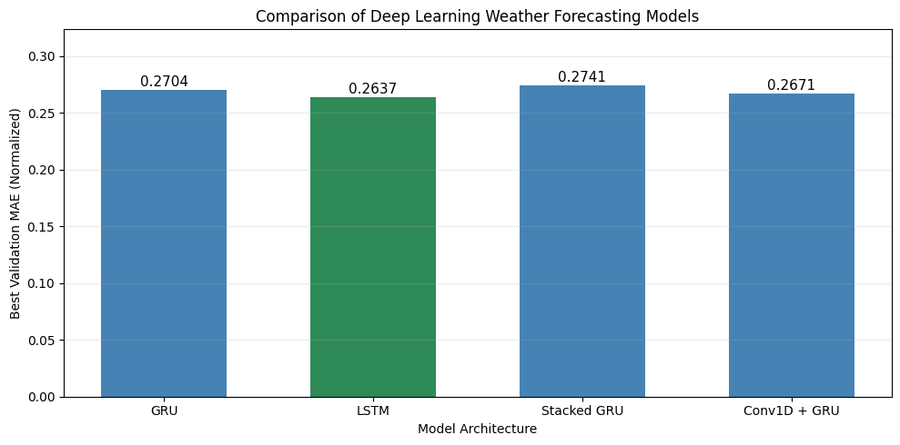

|  | Model | Validation MAE | Best Epoch |
| --- | --- | --- | --- |
| 0 | LSTM | 0.263740 | 27 |
| 1 | Conv1D + GRU | 0.267057 | 30 |
| 2 | GRU | 0.270388 | 10 |
| 3 | Stacked GRU | 0.274147 | 23 |

```
Best model: LSTM
Lowest validation MAE: 0.2637
```

```python
# Step 14 | Comparing all four weather forecasting models

# Collect validation MAE from the completed experiments
forecast_model_names = [
    "GRU",
    "LSTM",
    "Stacked GRU",
    "Conv1D + GRU"
]

forecast_validation_mae = [
    weather_gru_best_mae,
    weather_lstm_best_mae,
    weather_stacked_gru_best_mae,
    weather_hybrid_best_mae
]

# Identify the architecture with the lowest error
forecast_best_position = np.argmin(forecast_validation_mae)

# Highlight the best model in the comparison chart
forecast_bar_colors = [
    "seagreen" if index == forecast_best_position
    else "steelblue"
    for index in range(len(forecast_model_names))
]

plt.figure(figsize=(10, 5))

forecast_bars = plt.bar(
    forecast_model_names,
    forecast_validation_mae,
    color=forecast_bar_colors,
    width=0.6
)

# Display validation MAE above each bar
for forecast_bar, forecast_score in zip(
    forecast_bars, forecast_validation_mae
):
    plt.text(
        forecast_bar.get_x() + forecast_bar.get_width() / 2,
        forecast_bar.get_height() + 0.003,
        f"{forecast_score:.4f}",
        ha="center",
        fontsize=11
    )

plt.title("Comparison of Deep Learning Weather Forecasting Models")
plt.xlabel("Model Architecture")
plt.ylabel("Best Validation MAE (Normalized)")
plt.ylim(0, max(forecast_validation_mae) * 1.18)
plt.grid(axis="y", alpha=0.25)
plt.tight_layout()
plt.show()

# Summarize the comparison in a table
forecast_comparison_table = pd.DataFrame({
    "Model": forecast_model_names,
    "Validation MAE": forecast_validation_mae,
    "Best Epoch": [
        gru_best_epoch,
        weather_lstm_best_epoch,
        weather_stacked_gru_best_epoch,
        weather_hybrid_best_epoch
    ]
})

display(
    forecast_comparison_table.sort_values(
        "Validation MAE"
    ).reset_index(drop=True)
)

print(
    "Best model:",
    forecast_model_names[forecast_best_position]
)

print(
    "Lowest validation MAE:",
    round(min(forecast_validation_mae), 4)
)
```

### Overall Model Comparison

I compared four deep learning architectures to investigate how different recurrent layers and network structures affect weather forecasting performance.

The LSTM model achieved the lowest validation MAE of 0.2637, followed by the Conv1D + GRU hybrid model with 0.2671. The single-layer GRU achieved 0.2704, while the stacked GRU produced the highest validation MAE of 0.2741.

These results suggest that a more complex network does not always provide better predictions. Although the stacked GRU contained additional recurrent layers, it did not outperform the simpler LSTM model. The hybrid model performed better than both GRU configurations, suggesting that convolutional feature extraction may be useful for this forecasting task.

Based on validation MAE, I selected the LSTM model as the strongest architecture among the four experiments. I will evaluate this model on the separate testing dataset to examine how well it performs on weather observations that were not used during training or model selection.

```python
# Step 15 | Evaluating the selected LSTM on unseen weather data

# Evaluate the trained LSTM model on the test sequences
weather_test_loss, weather_test_mae = weather_lstm_model.evaluate(
    weather_test_x,
    weather_test_y,
    batch_size=128,
    verbose=1
)

# Generate temperature predictions
weather_test_predictions = weather_lstm_model.predict(
    weather_test_x,
    batch_size=128,
    verbose=0
).flatten()

# Retrieve training statistics for the temperature feature
weather_temperature_mean = weather_training_mean["T (degC)"]
weather_temperature_std = weather_training_std["T (degC)"]

# Convert predictions and actual temperatures into Celsius
weather_predicted_celsius = (
    weather_test_predictions * weather_temperature_std
    + weather_temperature_mean
)

weather_actual_celsius = (
    weather_test_y * weather_temperature_std
    + weather_temperature_mean
)

# Calculate prediction errors in Celsius
weather_test_mae_celsius = np.mean(
    np.abs(weather_actual_celsius - weather_predicted_celsius)
)

weather_test_rmse_celsius = np.sqrt(
    np.mean(
        (weather_actual_celsius - weather_predicted_celsius) ** 2
    )
)

# Display the final test results
print("\nFINAL LSTM TEST RESULTS")
print("----------------------------")

print(
    "Test MAE (normalized):",
    round(weather_test_mae, 4)
)

print(
    "Test MAE (°C):",
    round(weather_test_mae_celsius, 4)
)

print(
    "Test RMSE (°C):",
    round(weather_test_rmse_celsius, 4)
)

print(
    "Number of test predictions:",
    len(weather_test_predictions)
)
```

```
136/136 ━━━━━━━━━━━━━━━━━━━━ 1s 5ms/step - loss: 0.1349 - mae: 0.2854

FINAL LSTM TEST RESULTS
----------------------------
Test MAE (normalized): 0.2854
Test MAE (°C): 2.5028
Test RMSE (°C): 3.2208
Number of test predictions: 17380
```

### Final LSTM Model Evaluation

After comparing the four forecasting architectures, I selected the LSTM model because it achieved the lowest validation MAE.

I evaluated the selected model using the separate testing dataset, which was not used for training or choosing the best architecture. This allowed me to measure how well the model generalizes to unseen weather observations.

I converted the predicted and actual temperature values back into degrees Celsius to make the errors easier to interpret. I calculated Mean Absolute Error (MAE) to measure the average prediction error and Root Mean Squared Error (RMSE) to examine the effect of larger prediction errors.

These testing results provide a final evaluation of the selected LSTM forecasting model.

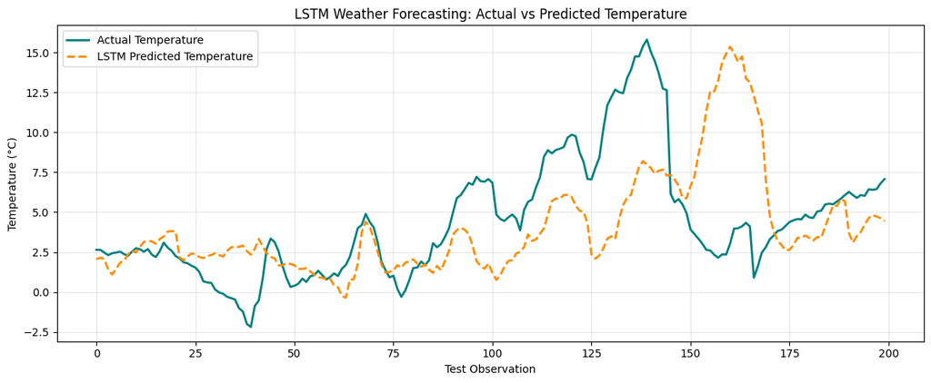

```
LSTM Test MAE (°C): 2.5028
LSTM Test RMSE (°C): 3.2208
```

```python
# Step 16 | Visualizing actual and predicted temperatures

# Select the first 200 observations for a readable graph
weather_plot_count = 200

weather_actual_sample = weather_actual_celsius[
    :weather_plot_count
]

weather_prediction_sample = weather_predicted_celsius[
    :weather_plot_count
]

# Plot actual and predicted temperature values
plt.figure(figsize=(12, 5))

plt.plot(
    weather_actual_sample,
    label="Actual Temperature",
    color="teal",
    linewidth=2
)

plt.plot(
    weather_prediction_sample,
    label="LSTM Predicted Temperature",
    color="darkorange",
    linestyle="--",
    linewidth=2
)

plt.title("LSTM Weather Forecasting: Actual vs Predicted Temperature")
plt.xlabel("Test Observation")
plt.ylabel("Temperature (°C)")
plt.legend()
plt.grid(alpha=0.3)
plt.tight_layout()
plt.show()

# Display the final forecasting errors
print("LSTM Test MAE (°C):", round(weather_test_mae_celsius, 4))
print("LSTM Test RMSE (°C):", round(weather_test_rmse_celsius, 4))
```

### Actual and Predicted Temperature Comparison

I plotted the actual temperature measurements alongside the predictions generated by my selected LSTM model. This visualization helps me examine how closely the predicted values follow the temperature changes in the testing dataset.

The model achieved a test MAE of 2.5028°C, meaning its predictions differed from the actual temperatures by approximately 2.50°C on average. The RMSE was 3.2208°C, indicating that larger prediction errors also occurred.

Although the model was able to learn useful patterns from historical weather observations, the prediction errors show that forecasting temperature 24 hours ahead remains challenging.

Overall, these results provide a practical evaluation of the LSTM model's ability to predict future temperatures using previously unseen weather data.

## Final Results and Conclusion

In this assignment, I explored how different deep learning architectures perform when predicting future temperatures using historical weather measurements from the Jena Climate dataset. I used five days of hourly weather observations to predict the temperature 24 hours ahead.

I experimented with four neural network architectures: a single-layer GRU, an LSTM, a stacked GRU, and a hybrid model combining Conv1D and GRU layers. I applied the same training and validation datasets and used early stopping to monitor model performance.

### Summary of Model Performance

| Model | Best Validation MAE (Normalized) |
| --- | --- |
| GRU | 0.2704 |
| LSTM | **0.2637** |
| Stacked GRU | 0.2741 |
| Conv1D + GRU | 0.2671 |

The LSTM model achieved the lowest validation MAE of 0.2637, making it the best-performing architecture among the four experiments. The Conv1D + GRU hybrid model performed slightly better than the single-layer GRU, while the stacked GRU produced the highest validation error.

One interesting observation was that increasing the number of recurrent layers did not necessarily improve forecasting accuracy. The stacked GRU was more complex than the single-layer models, but it did not achieve better validation results. This suggests that model complexity alone does not guarantee improved predictions.

### Final Test Evaluation

After selecting the LSTM model based on validation performance, I evaluated it using the separate testing dataset containing 17,380 prediction sequences.

The LSTM achieved a test MAE of **2.5028°C** and an RMSE of **3.2208°C**. The MAE indicates that the predicted temperatures differed from the actual values by approximately 2.50°C on average. The RMSE was higher because it gives greater weight to larger prediction errors.

## Final Conclusion

In this assignment, I explored how recurrent neural networks can be used to predict future temperatures from historical weather observations. I worked with the Jena Climate dataset and compared four different deep learning architectures: GRU, LSTM, stacked GRU, and a hybrid model combining Conv1D and GRU layers.

To make the comparison consistent, I used the same training, validation, and testing datasets across the experiments. I evaluated the models using mean absolute error (MAE), which helped me understand how closely their predictions matched the actual temperatures.

Among the four neural network models, LSTM achieved the lowest validation MAE of 0.2637, followed by Conv1D + GRU at 0.2671, GRU at 0.2704, and stacked GRU at 0.2741. I also included a simple baseline forecasting method, which produced a validation MAE of 0.2783. Comparing these results showed that LSTM improved upon the baseline by approximately 5.25%.

After selecting the two best-performing models based on validation MAE, I evaluated them on the unseen test dataset. LSTM achieved a test MAE of 2.5028°C and an RMSE of 3.2208°C, while Conv1D + GRU achieved a test MAE of 2.5279°C and an RMSE of 3.2342°C. Although the difference was small, LSTM performed slightly better on both measures.

One important observation from my experiments was that a more complex architecture did not necessarily provide better forecasting results. The stacked GRU model and the convolutional-recurrent hybrid did not outperform the single-layer LSTM in this experiment.

Overall, this assignment helped me understand how recurrent architectures learn patterns from time-series data and how validation and testing results can guide model selection. Based on my experiments, LSTM was the most effective approach for predicting temperature using the selected weather observations and forecasting setup.

```python
# Step 24 | Establishing a simple forecasting baseline

# Use the last observed temperature in each validation sequence
baseline_val_predictions = weather_val_x[
    :, -1, weather_temperature_index
]

# Compare baseline predictions with actual future temperatures
baseline_val_mae = np.mean(
    np.abs(weather_val_y - baseline_val_predictions)
)

# Convert normalized error into degrees Celsius
baseline_val_mae_celsius = (
    baseline_val_mae * weather_training_std["T (degC)"]
)

print("Baseline validation MAE (normalized):",
      round(baseline_val_mae, 4))

print("Baseline validation MAE (°C):",
      round(baseline_val_mae_celsius, 4))

print("LSTM validation MAE (normalized):",
      round(weather_lstm_best_mae, 4))

if weather_lstm_best_mae < baseline_val_mae:
    print("LSTM performs better than the baseline.")
else:
    print("The baseline performs better than or equal to LSTM.")
```

```
Baseline validation MAE (normalized): 0.2783
Baseline validation MAE (°C): 2.4409
LSTM validation MAE (normalized): 0.2637
LSTM performs better than the baseline.
```

```python
# Step 26 | Evaluating the hybrid model on unseen weather data

# Evaluate the existing Conv1D + GRU model
hybrid_test_loss, hybrid_test_mae = weather_hybrid_model.evaluate(
    weather_test_x,
    weather_test_y,
    batch_size=128,
    verbose=1
)

# Generate predictions using the trained hybrid model
hybrid_test_predictions = weather_hybrid_model.predict(
    weather_test_x,
    batch_size=128,
    verbose=0
).flatten()

# Convert normalized predictions into degrees Celsius
hybrid_predicted_celsius = (
    hybrid_test_predictions * weather_temperature_std
    + weather_temperature_mean
)

# Calculate the hybrid model's test MAE in Celsius
hybrid_test_mae_celsius = np.mean(
    np.abs(weather_actual_celsius - hybrid_predicted_celsius)
)

# Calculate RMSE in Celsius
hybrid_test_rmse_celsius = np.sqrt(
    np.mean(
        (weather_actual_celsius - hybrid_predicted_celsius) ** 2
    )
)

# Display both models' testing results
print("\nFINAL TEST PERFORMANCE COMPARISON")
print("--------------------------------")

print("LSTM Test MAE (°C):",
      round(weather_test_mae_celsius, 4))

print("Hybrid Test MAE (°C):",
      round(hybrid_test_mae_celsius, 4))

print("LSTM Test RMSE (°C):",
      round(weather_test_rmse_celsius, 4))

print("Hybrid Test RMSE (°C):",
      round(hybrid_test_rmse_celsius, 4))

print("Hybrid Test MAE (normalized):",
      round(hybrid_test_mae, 4))
```

```
136/136 ━━━━━━━━━━━━━━━━━━━━ 1s 5ms/step - loss: 0.1360 - mae: 0.2882

FINAL TEST PERFORMANCE COMPARISON
--------------------------------
LSTM Test MAE (°C): 2.5028
Hybrid Test MAE (°C): 2.5279
LSTM Test RMSE (°C): 3.2208
Hybrid Test RMSE (°C): 3.2342
Hybrid Test MAE (normalized): 0.2882
```

### Final Test Comparison: LSTM and Conv1D + GRU

After comparing the validation results of all four neural network architectures, I evaluated the two best-performing models, LSTM and Conv1D + GRU, using the separate testing dataset.

The LSTM model achieved a test MAE of 2.5028°C and an RMSE of 3.2208°C. The Conv1D + GRU hybrid model produced a slightly higher test MAE of 2.5279°C and an RMSE of 3.2342°C.

The difference in test MAE was only 0.0251°C, indicating that both models performed similarly on unseen weather observations. However, LSTM achieved the lower prediction error on both evaluation metrics.

These results support my earlier validation findings, where LSTM also achieved the lowest MAE. Although combining convolutional and recurrent layers produced competitive results, the simpler LSTM architecture performed slightly better in my experiments.

Overall, the LSTM model was the strongest forecasting approach among the architectures I tested. The comparison also showed that adding more layers or combining different layer types does not always guarantee better prediction accuracy.

### Final Performance Summary

The following table summarizes the validation performance of all four neural network architectures and the baseline forecasting method.

| Model | Validation MAE (Normalized) |
| --- | --- |
| Baseline Forecast | 0.2783 |
| GRU | 0.2704 |
| LSTM | **0.2637** |
| Stacked GRU | 0.2741 |
| Conv1D + GRU | 0.2671 |

The LSTM achieved the lowest validation error, improving upon the baseline by approximately 5.25%.

### Final Test Results

| Model | Test MAE (°C) | Test RMSE (°C) |
| --- | --- | --- |
| LSTM | **2.5028** | **3.2208** |
| Conv1D + GRU | 2.5279 | 3.2342 |

Both models performed similarly on the unseen test dataset, but LSTM achieved slightly lower prediction errors. This supports selecting LSTM as the final forecasting model for this assignment.